# GladiaTOX: R Package for Processing High Throughput Screening data

Vincenzo Belcastro

Philip Morris Products, S.A.  
Vincenzo.Belcastro@contracted.pmi.com

Stephane Cano

Philip Morris Products, S.A.  
Stephane.Cano@pmi.com

Florian Martin

Philip Morris Products, S.A.  
Florian.Martin@pmi.com

#### Package version: GladiaTOX

# 1 Introduction

GladiaTOX is an open-source solution for HCS data processing and reporting that expands the tcpl package (toxcast pipeline, *Filer et al., 2016*). In addition to tcpl’s functionalities (multiple dose-response fitting and best fit selection), GladiaTOX

- Fetches raw image quantifications via a webservice layer, also allowing multiple (proprietary) systems to be integrated easily
- Computes MEC based also on historical data
- Exports results formatted for ToxPI GUI
- Aggregates single endpoint MECs into severity scores
- Implements a suite of functionalities for QC and processing reporting to structured PDF files

## 1.1 Deployed database

The GladiaTOX installatioin includes the deployment of a sqlite database (`sql/gladiatoxdb.sqlite` folder). The database already contains fully processed study, with

- asid: 1 (assay source id), the unique study identifier
- asnm: S167320 (assay source name), the names of the study
- asph: HCAEC (assay source phase), the phase that in this case corresponds to the cell type of the study phase: human coronary artery endothelial cells

```r
library(GladiaTOX)
# Set output directory for reporting
outdir <- getwd()
```

```r
tcplLoadAsid()
```

```
#>    asid    asnm  asph
#> 1:    1 S167320 HCAEC
```

This database will be used in next sections to load and process a second study phase. The sqlite database can be seen as a sample database used for the following excercise. In case you plan to use the package for multiple studies we recommend to install the MySQL database (`sql/gladiatoxdb_structure.mysql`).

## 1.2 Database configuration

The first step after database deployment id to set the correct cofiguration paraters to access. The default configuration already points to the sqlite database at

```
#> [1] "/install_dir/sql/gladiatoxdb.sqlite"
```

so no additional configurations are needed to complete the exercise below.

In case you install the database schema or change location of the sqlite database, then you must run the configuration command below and point to the new database location. The following command assumes the new database is installed at `my_folder_path`

```r
tcplConf(drvr = "SQLite",
         host = NA,
         user = NA,
         pass = NULL,
         db = "/my_folder_path/gladiatoxdb.sqlite")
```

In case you deploy the database schema provided in the sql folder, then change the driver (drvr) to `MySQL`. Eventually you may need to configure your user name and password.

Below is an example of configuration call that point to an MySQL database called `my_gl_database` at `local.host`:

```r
tcplConf(drvr = "MySQL",
         host = "local.host",
         user = "username",
         pass = "********",
         db = "my_gl_database")
```

# 2 Data and metadata for vignette

In this section we will explore one simple way of loading data in the database prior data processing and reporting. It consists in preparing the metadata and data in R objects (data.frame) prior database loading. The package offers additional functionalities that we will explore to setup the data appropriately. We will also discuss a second way of loading the data from Thermo database, and briefly discuss ho to setup the package for that.

## 2.1 `plate`: plate metadata

The `plate` object stores metadata with plate information.

```r
head(plate)
```

```
#>     stimulus stimulus concentration exposure duration plate tube well_type
#>  o-anisidine               10000 uM               24h     1   A1         t
#>  o-anisidine                5000 uM               24h     1   B1         t
#>  o-anisidine                1000 uM               24h     1   C1         t
#>  o-anisidine                 200 uM               24h     1   D1         t
#>  o-anisidine             0.00007 uM               24h     1   E1         t
#>  o-anisidine           0.0000006 uM               24h     1   F1         t
#>  vehicle_name   study study.phase cell type    endpoint exposure date
#>          EtOH S167320    vignette      NHBE GSH content    2014-06-17
#>          EtOH S167320    vignette      NHBE GSH content    2014-06-17
#>          EtOH S167320    vignette      NHBE GSH content    2014-06-17
#>          EtOH S167320    vignette      NHBE GSH content    2014-06-17
#>          EtOH S167320    vignette      NHBE GSH content    2014-06-17
#>          EtOH S167320    vignette      NHBE GSH content    2014-06-17
#>  plate_set Biological Replicate smoke ID well format           assay
#>          0                    1  NOSMKID     96-well GSH content_24h
#>          0                    1  NOSMKID     96-well GSH content_24h
#>          0                    1  NOSMKID     96-well GSH content_24h
#>          0                    1  NOSMKID     96-well GSH content_24h
#>          0                    1  NOSMKID     96-well GSH content_24h
#>          0                    1  NOSMKID     96-well GSH content_24h
#>        Date  u_boxtrack
#>  2014-03-17 S-000031334
#>  2014-03-17 S-000031334
#>  2014-03-17 S-000031334
#>  2014-03-17 S-000031334
#>  2014-03-17 S-000031334
#>  2014-03-17 S-000031334
```

Most of the columns have self-contained names and content; `plate` is the plate number (usually an integer); `tube` is the well location (H1 is row 8 column 1); `well_type` is the content type of the well (`c` positive control, `t` treatment, `n` is the negative control); `enpoint` contains assay names with no exposure duration info appended; `u_boxtrack` is a plate identifier used to join the `plate` metadata table with the raw data table (or the raw data from Thermo database) prior data is loaded in the GladiaTOX database.

## 2.2 `chnmap`: assay metadata and channel mapping

The second metadata table contains assay mapping information. In the example below this table contains two assays: *Cytotoxicity (TIER1)* and *DNA damage (pH2AX)*.

```r
head(chnmap, 7)
```

```
#>                 Assay                         Endpoint
#>  Cytotoxicity (TIER1)                       Cell count
#>  Cytotoxicity (TIER1)       Cell membrane permeability
#>  Cytotoxicity (TIER1) Mitochondrial membrane potential
#>  Cytotoxicity (TIER1)               Mitochondrial mass
#>  Cytotoxicity (TIER1)             Cytochrome C release
#>    DNA damage (pH2AX)                       Cell count
#>    DNA damage (pH2AX)               DNA damage (pH2AX)
#>                           Channel
#>  SelectedObjectCountPerValidField
#>              MEAN_CircAvgIntenCh2
#>          MEAN_RingSpotAvgIntenCh3
#>         MEAN_RingSpotTotalAreaCh3
#>              MEAN_CircAvgIntenCh4
#>  SelectedObjectCountPerValidField
#>              MEAN_CircAvgIntenCh2
```

Five endpoints are part of the cytotoxicity assay (e.g., *Cell count*, *membrane permeability*). Two endpoints are shown to be part of the DNA damage assay. Since multiple endpoints can be read from the same plate, each of them is read on a separate channel. This column will also be used later on to join meatadata and data tables).

The content of `plate` and `chnmap` are then combined to generate the `assay` table. In the `assay` table, assay and endpoint are concatenated to timepoints to generate assays entries for the database.

```r
assay <- GladiaTOX:::.buildAssayTab(plate, chnmap)
```

## 2.3 `dat`: image quantification raw data

The data table is an export from the image quantification instrument.

```r
head(dat)
```

```
#>  measure_val rowi coli                     machine_name  u_boxtrack
#>       134.15    1    1 SelectedObjectCountPerValidField S-000031358
#>       118.50    1    2 SelectedObjectCountPerValidField S-000031358
#>       139.05    1    3 SelectedObjectCountPerValidField S-000031358
#>       214.50    1    4 SelectedObjectCountPerValidField S-000031358
#>       226.55    1    5 SelectedObjectCountPerValidField S-000031358
#>       229.75    1    6 SelectedObjectCountPerValidField S-000031358
```

This table contains the raw fluoroscence quantification values: `measure_val`; `rowi` and `coli` are the row and column indexes; `machine_name` is the channel name and is used to join this table with the assay table above; `u_boxtrack` is the plate identified and is used to join the table with the plate table.

# 3 Database loading

In this sections data and metadata will be loaded in the GladiaTOX database. Let’s set the study paramenters, study name and phase of the new study to be loaded in the database and processed.

```r
## Set study paramenters
std.nm <- "S167320" # study name
phs.nm <- "vignette" # study phase
```

## 3.1 Register study info in database

The following code will register metadata file content in the database, including: assays, endpoint, treatments and controls. The status of the assay source table (study table) before and after new study creation is displayed below.

```r
## List of studies before loading
tcplLoadAsid()
```

```
#>    asid    asnm  asph
#> 1:    1 S167320 HCAEC
```

```r
## Load annotation in tcplDB
loadAnnot(plate, assay, NULL)
```

```
#> [1] TRUE
```

```r
## List of studies after loading
tcplLoadAsid()
```

```
#>    asid    asnm     asph
#> 1:    1 S167320    HCAEC
#> 2:    2 S167320 vignette
```

The `loadAnnot` function call registers multiple study paramenters in the database, including the creation of the new assay source id (asid). The asid identifies the pair study name, study phase. The asid is what will be used to load raw data of the study, process the study and generate reports.

## 3.2 Load raw data in database

The `asid` just created can be retrieved by querying the database and specify the study name and phase.

```r
# Get assay source ID
asid = tcplLoadAsid(fld = c("asnm", "asph"), val = list(std.nm, phs.nm))$asid
print(asid)
```

```
#> [1] 2
```

The `asid` and the `dat` object are the inputs to the `prepareDatForDB` function used to join metadata stored in database to the raw data stored in the `dat} object.

```r
# Prepare and load data
dat <- prepareDatForDB(asid, dat)
tcplWriteData(dat[ , list(acid, waid, wllq, rval)], lvl = 0, type = "mc")
```

```
#> Completed delete cascade for 34 ids (0.08 secs)
#> [1] TRUE
```

Then the raw data is loaded in the database with the `tcplWriteData` function. Study whose `asid` is `2` is now ready to be processed.

# 4 Quality control: data processing and reporting

Metadata and data are now registered in the database. Next step is to select the processing methods we want to apply on the data. There are multiple levels of processing (see *Filer et al., 2016* foe details). The fucntion `assignDefaultMthds` is a shortcut to assign all levels methods at once. The methods selected would probably fit well to most users.

```r
assignDefaultMthds(asid = asid)
```

with the default selection, raw data is normalized by computing the log2 fold change of values in each well against the median of the corresponding controls.

## 4.1 Compute the noise band

The package computes a noise band to discriminate concentration series that are active versus those that are not. The default behaviour is to compute noise band margins separetely for each endpoint. Margins correspond to 3 times the baseline absolute deviation of vehicle responses. The following instructions compute the cutoffs and store them in the database.

```r
res <- tcplRun(asid = asid, slvl = 1, elvl = 3)
aeids <- tcplLoadAeid(fld = "asid", val = asid)$aeid
tmp <- mapply(function(xx){
    tryCatch(tcplCalcVmad(inputs = xx, aeid = xx,
                          notes = "computed within study"),
             error = function(e) NULL)},
    as.integer(aeids))
res <- tcplRun(asid = asid, slvl = 1, elvl = 6)
```

In the original work (*Filer et al., 2016*), the default behaviour is to compute noise band margins based on the response of the lowest two concetrations of the series. That assumes that no response is observed at those concentrations. The current package overcome that assumption and extend the list of functionalities. The database design is modified accordingly.

## 4.2 Quality control report

Quality control is the mean to check the quality of the data produced in the lab. Each experimental plate is controlled. Plates not passing the control step are filtered out. Quality control is commonly based on a visual inspection. The packace exposes functionalities to generate a self contained pdf file with plate heatmaps and positive control plots.

```r
## QC report
tcplReport(type = "qc", asid = asid, report_author = "report author",
           report_title = "Vignette QC report", odir = outdir)
```

An example of plate heatmap is shown below, and is what included in the quality control pdf report.

```r
acnm <- "DNA damage (pH2AX)_DNA damage (pH2AX)_4h"
myaid <- tcplLoadApid()[u_boxtrack == "S-000031351", aid]
myaid <- myaid[myaid%in%tcplLoadAid(fld = "asid", val = asid)$aid]
apid <- tcplLoadApid()[u_boxtrack == "S-000031351" & aid == myaid, apid]
acid <- tcplLoadAcid(fld = c("aid", "acnm"), val = list(myaid, acnm))[, acid]
l2 <- tcplLoadData(lvl = 2L, fld = "acid", val = acid)
```

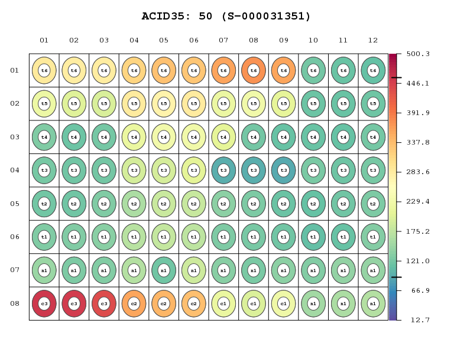

Example of heatmap of a plate raw values. Letters in well indicate the well type.

```r
tcplPlotPlate(dat = l2, apid = apid, id = acid)
```

The QC report will also include dose-response for positive control chemicals as in figure.

```r
aeid <- tcplLoadAeid(fld = c("acid", "analysis_direction"), val = list(acid, "up"))[, aeid]
spid <- tcplLoadWaid(fld = c("apid", "wllt"), val = list(apid, "c"))[,unique(spid)]
m4id <- tcplLoadData(lvl = 4L, fld = c("spid", "aeid"), val = list(spid, aeid))[, m4id]
```

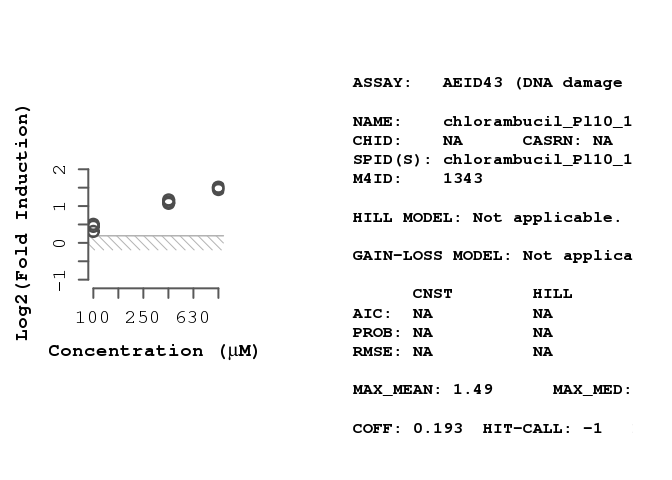

Example of Positive control (chlorambucil chemical) plot with three concentrations, and three technical replicates per concentration.

```r
tcplPlotM4ID(m4id = m4id, lvl = 6, bline = "coff")
```

The panel on the right side shows a set of information including goodness of fit values (AIC, PROB, and RMSE). In this particular eaxmple no info is available since the series has to few concentration (4 concentrations is the minimum number to perform a fit).

### 4.2.1 Data masking

QC report is mainly used to check the quality of the plates. For example, in case the respose of a positive control of an assay stays within the noiseband, then the user may decide to filter that plate out. Below is shown the code to mask plate *S-000030318*.

```r
apid <- tcplLoadApid()[u_boxtrack%in%"S-000030318", apid] # plate id
waids <- tcplLoadWaid(fld="apid", val=apid)$waid #well ids
m0ids <- tcplLoadData(lvl = 0, fld = "waid", val = waids)$m0id # raw data ids
tcplSetWllq(ids = m0ids, wllq = 0, type = "mc") # set well quality to zero
```

```
#> Completed delete cascade for 7 ids (0.14 secs)
#> [1] TRUE
```

The masked plate will not be processed and included in the final report.

# 5 Data processing and reporting

## 5.1 Process data

Now that the user has selected the processing methods, the cutoff are computed, and bad quality plates masked, all information is in palce to start processing the data. The following instruction does all the 6 levels processing.

```r
res <- tcplRun(asid = asid, slvl = 1, elvl = 6)
```

The `tcplRun` returns a list of logical vectors the check processign status. The resulting processed data is stored in the database along with the statistics computed. Satistics include activity concentrations (AC10 and AC50) and minimal effective concentrations (MECs).

## 5.2 Data reporting

The `tcplReport` function, with option `type = "all"`, triggers the generation of the full processing report. The pdf file created includes summary tables, dose-response curves (as seen later), and other plots for all chemicals tested in the study.

```r
## Processing report
tcplReport(type = "all", asid = asid, report_author = "report author",
           report_title = "Vignette Processing report", odir = outdir)
```

Best model fitting are included in the final report. In order to select the best the package evaluate three models: constant, hill and gain-loss. Below is shown an example where all models are fit to the data (ochre, red and blue) from a single plate.

```r
## Endpoint to plot
aeids <- tcplLoadAeid(fld=c("asid", "aenm"),
            val=list(asid, "DNA damage (pH2AX)_DNA damage (pH2AX)_24h_up"),
            add.fld="asid")$aeid
## level 4 id to plot
m4id <- tcplLoadData(lvl=4L)[(aeid==aeids & grepl("chromium", spid))]$m4id[1]
```

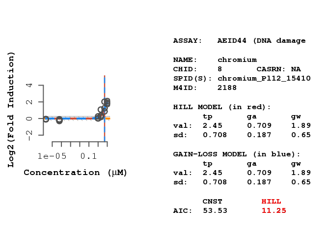

Best fit selection.

```r
tcplPlotM4ID(m4id = m4id, lvl = 6, bline = "coff")
```

The HILL model (marked in red on the right panel) will be selected as best fit since minimizing the Akaike information criteria (AIC).

All winning models are combined into a single plot that is included in the pdf report. An example of winning models plot is shown in figure, for the very same chemical and endpoint shown above.

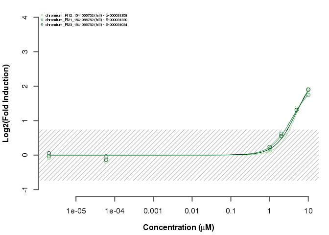

Example of dose-response curves.

```r
## Get chemical id to plot
chid <- tcplLoadChem(field = "chnm", val = "chromium",
                     include.spid = FALSE)$chid
## Plot dose-response curves
tcplPlotWin(chid = chid, aeid = aeids, bline = "bmad", collapse = TRUE)
```

The plot shows all replicated dose-response curves. Each curve represents the fitting result on an experimental plate. Only best fits are reported.

# 6 Additional reporting plots

Additional reporting plots, not included in the full report, can be obtained as described below. Boxplot of minimal effective concentrations can be obtained running the following chunk.

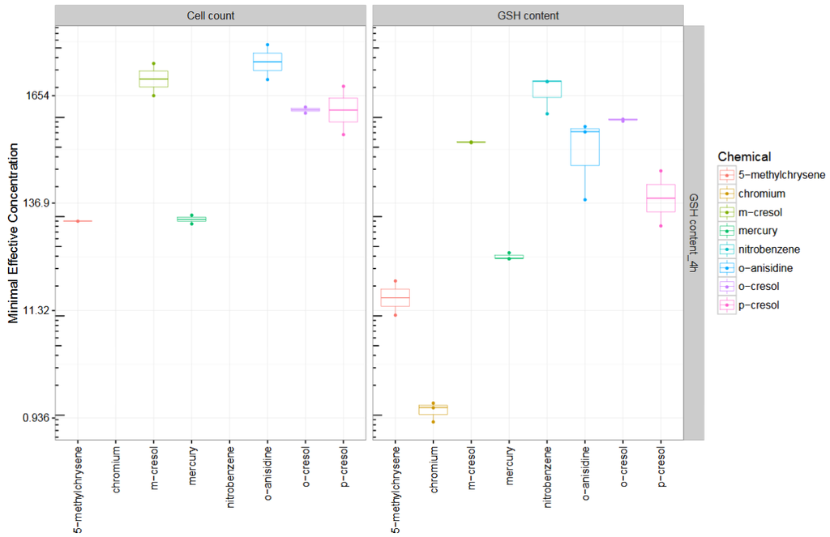

```r
fname <- paste0(format(Sys.Date(), format="%y%m%d"), "_ASID", asid,"_MEC.pdf")
fname <- file.path(outdir, fname)
pdf(fname, width = 11, height = 7)
glPlotStat(asid)
dev.off()
```

An exmaple of boxplot is reported below. MEC values are shown as dots. Low MECs correspond to high toxicity.

MEC values can also be reported in a piechart. Below an example. Here chemicals are displayed side-by-side. Values associated to pies indicate mean MECs.

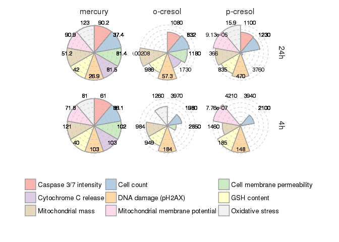

Example of pie plots. The figure shows three chemicals and all endpoints.

```r
chnms <- c("mercury", "o-cresol", "p-cresol")
glPlotPie(asid, chnms = chnms)
```